# AI_CA4

### Implementation

```python
KNN_model = KNeighborsClassifier(n_neighbors=200)
KNN_model.fit(X_train, y_train)
```

```
KNeighborsClassifier(n_neighbors=200)
```

### Accuracy

```
KNN Accuracy is : 84.15 %
```

[figure not shown]

```python
print(f'KNN Accuracy is : {KNN_model.score(X_test, y_test) * 100:.2f} %')
plot_confusion_matrix(y_test,log_reg_model.predict(X_test), "KNN")
```

### Decision Tree

Decision trees are intuitive machine learning models used for classification and regression. They make a sequence of decisions based on features to predict outcomes. The tree structure consists of nodes, branches, and leaves. At each node, a feature is chosen to split the data, creating child nodes. The process continues recursively until a stopping criterion is met. Leaf nodes represent predictions. Decision trees are easy to understand and handle various data types, but they can overfit. Pruning and ensemble methods can address overfitting. Decision trees are popular for their interpretability and versatility.

### Implementation

```python
decision_tree_model = DecisionTreeClassifier(random_state=60)
decision_tree_model.fit(X_train, y_train)
```

```
DecisionTreeClassifier(random_state=60)
```

### Accuracy

```
Decision Tree Accuracy is : 88.39 %
```

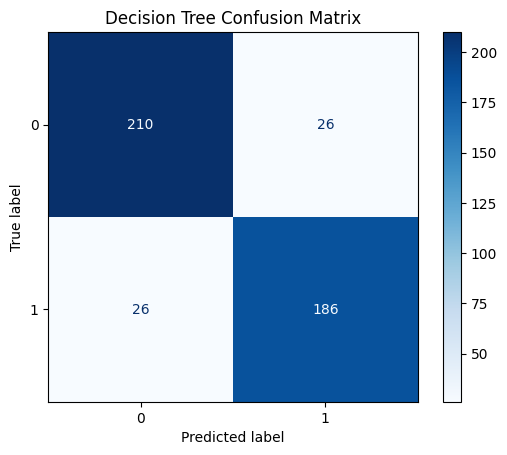

```python
print(f'Decision Tree Accuracy is : {decision_tree_model.score(X_test, y_test) * 100:.2f} %')
plot_confusion_matrix(y_test,decision_tree_model.predict(X_test), "Decision Tree")
```

### Q20

`GridSearchCV` is a method in scikit-learn that performs an exhaustive search over a specified parameter grid to find the best combination of hyperparameters for a given estimator. The input parameters are :

1. `estimator`: The estimator object that will be used to fit the data.
2. `param_grid`: A dictionary or a list of dictionaries that specifies the hyperparameters to search over.
3. `cv`: The cross-validation strategy to use.
4. `scoring`: The scoring metric to use to evaluate the performance of the model.
5. `n_jobs`: The number of CPU cores to use for parallel processing. Setting `n_jobs=-1` will use all available CPU cores.
6. `verbose`: The level of verbosity during the search process. Setting `verbose=1` will print progress messages during the search.

### Logistic regression

It has several hyperparameters that can be tuned to improve the performance of the model. we use the top three here :

1. `Penalty`: Logistic regression can use either L1 or L2 regularization to prevent overfitting. The `penalty` hyperparameter controls which type of regularization to use. L1 regularization can be used to perform feature selection by setting some coefficients to zero, while L2 regularization can be used to shrink the coefficients towards zero.
2. `C`: The `C` hyperparameter controls the strength of the regularization. A smaller value of `C` results in stronger regularization, which can help prevent overfitting but may also lead to underfitting.
3. `Solver`: Logistic regression can use different optimization algorithms to find the optimal coefficients. The `solver` hyperparameter controls which algorithm to use. The most common solvers are *lbfgs*, *liblinear*, *newton-cg*, *sag*, *saga*.

```python
log_reg_serach = GridSearchCV(
    estimator=LogisticRegression(),
    param_grid={
    "C": [0.01, 0.1, 1, 10, 100],
    "penalty": ["l2"],
    "solver": ["newton-cg", "lbfgs", "liblinear", "sag", "saga"],
    },
    scoring="accuracy",
    cv=5,
    n_jobs=-1,
)

log_reg_serach.fit(X_train, y_train)

print(f"Best Accuracy is : {log_reg_serach.score(X_test, y_test) * 100:.2f} %")
print(f"Logistic Regression Accuracy is : {log_reg_model.score(X_test, y_test) * 100:.2f} %")
print(f"Best Parameters are : {log_reg_serach.best_params_}")
```

```
Best Accuracy is : 86.38 %
Logistic Regression Accuracy is : 86.16 %
Best Parameters are : {'C': 10, 'penalty': 'l2', 'solver': 'newton-cg'}
```

#### KNN

The most important hyperparameter and the only one that KNN has is `k` which is the number of its neighbors. beside that we use two more factor which effect the model's performance :

1. `n_neighbors`: The number of neighbors `k` to consider when making a prediction. A larger value of `k` can help reduce the effect of noise in the data, but may also lead to underfitting. A smaller value of `k` can help capture more complex patterns in the data, but may also lead to overfitting.
2. `algorithm`: The algorithm used to compute the nearest neighbors. the options are *auto* ,*ball_tree*, *kd_tree*, and *brute*.
3. `metric`: The distance metric to use for the tree.

```python
KNN_grid_search = GridSearchCV(
    estimator=KNeighborsClassifier(),
    param_grid={
        "n_neighbors": list(range(1, 11)) + list(range(20, 101, 10)),
        "metric": ["euclidean", "manhattan", "minkowski"],
        "algorithm": ["auto", "ball_tree", "kd_tree", "brute"]
    },
    scoring="accuracy",
    cv=5,
    n_jobs=-1,
)

KNN_grid_search.fit(X_train, y_train)


print(f"Best Accuracy is : {KNN_grid_search.score(X_test, y_test) * 100:.2f} %")
print(f"KNN Accuracy: {KNN_model.score(X_test, y_test) * 100:.2f} %")
print(f"Best Parameters are : {KNN_grid_search.best_params_}")
```

```
Best Accuracy is : 89.51 %
KNN Accuracy: 84.15 %
Best Parameters are : {'algorithm': 'auto', 'metric': 'manhattan', 'n_neighbors': 20}
```

#### Decision Tree

Here are the most important hyperparameters of decision trees that we selected to use:

1. `criterion`: The function used to measure the quality of a split. The two options availabel are *gini* and *entropy*.
2. `max_depth`: The maximum depth of the decision tree. A larger value of `max_depth` can capture more complex patterns in the data, but may also lead to overfitting. A smaller value of `max_depth` may lead to underfitting.
3. `min_samples_split`: The minimum number of samples required to split an internal node.
4. `min_samples_leaf`: The minimum number of samples required to be at a leaf node.
5. `splitter`: The strategy used to choose the split at each node. The two options here are *random* and *best*.

```python
decision_tree_search = GridSearchCV(
    estimator=DecisionTreeClassifier(),
    param_grid={
        "criterion": ["gini", "entropy"],
        "splitter": ["best", "random"],
        "max_depth": range(2, 9),
        "min_samples_split": range(2, 9),
        "min_samples_leaf": range(2, 9),
        "random_state": [54],
    },
    scoring="accuracy",
    cv=5,
    n_jobs=-1,
)

decision_tree_search.fit(X_train, y_train)

print(f"Best Accuracy is : {decision_tree_search.score(X_test, y_test) * 100:.2f} %")
print(f"Decision Tree Accuracy is : {decision_tree_model.score(X_test, y_test) * 100:.2f} %")
print(f"Best Parameters are : {decision_tree_search.best_params_}")
```

```
Best Accuracy is : 89.73 %
Decision Tree Accuracy is : 88.39 %
Best Parameters are : {'criterion': 'gini', 'max_depth': 2, 'min_samples_leaf': 2, 'min_samples_split': 2, 'random_state': 54, 'splitter': 'best'}
```

### Q21

`Overfitting` occurs when a model becomes too specialized to the training data, memorizing noise and performing poorly on new data. It happens when the model is too complex or the training data is too limited.

`Underfitting` happens when a model is too simple and fails to capture the underlying patterns in the data. It leads to poor performance on both training and new data.

To address *overfitting*, you can increase the training data, simplify the model, or use regularization techniques. To address *underfitting*, you can increase the model's complexity, improve the data, or try a more advanced model.

The goal is to find the right balance between complexity and generalization to achieve optimal model performance.

```python
best_log_reg = LogisticRegression(**log_reg_serach.best_params_)
best_log_reg.fit(X_train, y_train)
print(f'Logistic Regression Accuracy in train data is : {best_log_reg.score(X_train, y_train) * 100:.2f} %')
print(f'Logistic Regression Accuracy in test data is : {best_log_reg.score(X_test,y_test) * 100:.2f} %')
print("----------------------------------------------------------")

best_KNN= KNeighborsClassifier(**KNN_grid_search.best_params_)
best_KNN.fit(X_train, y_train)
print(f'KNN Accuracy in train data is : {best_KNN.score(X_train, y_train) * 100:.2f} %')
print(f'KNN Accuracy in test data is : {best_KNN.score(X_test,y_test) * 100:.2f} %')
print("----------------------------------------------------------")

best_decision_tree = DecisionTreeClassifier(**decision_tree_search.best_params_)
best_decision_tree.fit(X_train, y_train)
print(f'Decision Tree Accuracy in train data is : {best_decision_tree.score(X_train, y_train) * 100:.2f} %')
print(f'Decision Tree Accuracy in test data is : {best_decision_tree.score(X_test,y_test) * 100:.2f} %')
```

```
Logistic Regression Accuracy in train data is : 90.90 %
Logistic Regression Accuracy in test data is : 86.38 %
----------------------------------------------------------
KNN Accuracy in train data is : 92.19 %
KNN Accuracy in test data is : 89.51 %
----------------------------------------------------------
Decision Tree Accuracy in train data is : 92.58 %
Decision Tree Accuracy in test data is : 89.73 %
```

As we can see both of the scores are pretty good and we don't have overfitting or underfitting. A more important point to notice here is that because we are using the best params the train score tends to be high.

### Q22

Preprocessing is an extremely important step in machine learning. The preprocessing steps have been changed a lot to reach the percentages seen before.  
An example would be the threshold for correlation to keep.

### Q23

Here we use the `plot_tree` from sklearn library.

```
[Text(0.5, 0.8333333333333334, 'x[6] <= -0.458\ngini = 0.499\nsamples = 1792\nvalue = [862, 930]'),
```

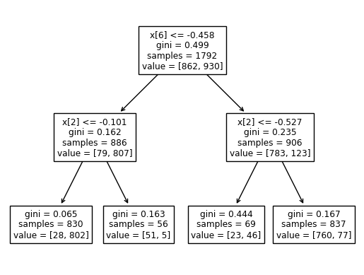

```python
plot_tree(best_decision_tree)
```

## Ensemble Learning

### Q24

Random Forest is an ensemble learning method that combines multiple decision trees to improve the performance of the model and to reduce the variance. some of the hyperparameters are :

1. `n_estimators`: The number of decision trees in the Random Forest. A larger value of `n_estimators` can improve the performance of the model, but may also increase the training time and memory usage.
2. `criterion`: The function used to measure the quality of a split. The options are *gini* and *entropy*.
3. `max_depth`: The maximum depth of the decision trees in the Random Forest.
4. `min_samples_split`: The minimum number of samples required to split an internal node. A larger value of **min_samples_split** can help prevent overfitting but may also lead to underfitting.
5. `max_features`: The maximum number of features to consider when making a split.

### Implement

Here first we train a forest with `GridSearchCV` to find the best parametrs.

```
Best Accuracy is : 92.19 %
Random Forest Accuracy is: 91.29 %
Best Parameters: {'criterion': 'entropy', 'max_depth': 8, 'min_samples_split': 4, 'n_estimators': 18, 'random_state': 54}
```

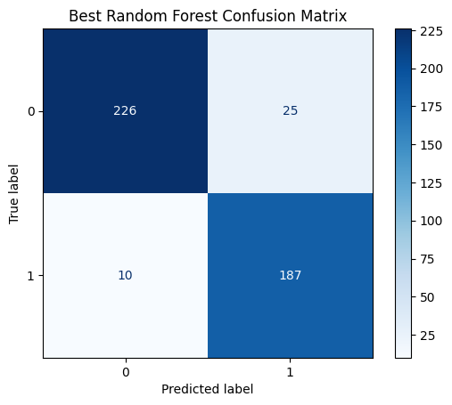

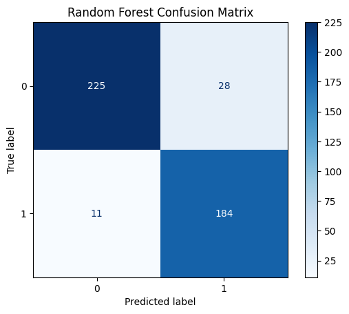

```python
forest_grid_search = GridSearchCV(
    estimator=RandomForestClassifier(),
    param_grid={
        "n_estimators": range(2,21,2),
        "criterion": ["gini", "entropy"],
        "max_depth": range(2, 12) ,
        "min_samples_split": range(2, 5),
        "random_state": [54],
    },
    scoring="accuracy",
    cv=5,
    n_jobs=-1,
)

forest_grid_search.fit(X_train, y_train)
forest_model = RandomForestClassifier()
forest_model.fit(X_train, y_train)

print(f"Best Accuracy is : {forest_grid_search.score(X_test, y_test) * 100:.2f} %")
print(f"Random Forest Accuracy is: {forest_model.score(X_test, y_test) * 100:.2f} %")
print(f"Best Parameters: {forest_grid_search.best_params_}")

forest_grid_search.estimator = RandomForestClassifier(**forest_grid_search.best_params_)
forest_grid_search.estimator.fit(X_train, y_train)
plot_confusion_matrix(y_test,forest_grid_search.estimator.predict(X_test), "Best Random Forest")
plot_confusion_matrix(y_test,forest_model.predict(X_test), "Random Forest")
```

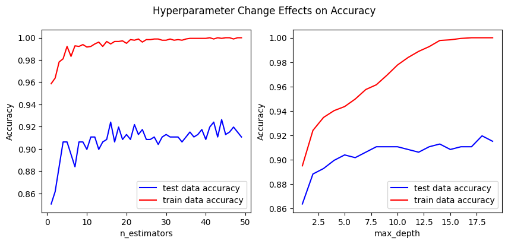

```python
n_estimators_range = range(1, 50)
max_depth_range = range(1, 20)

plt.figure(figsize=(10, 4))
plt.suptitle('Hyperparameter Change Effects on Accuracy')
plt.subplot(1, 2, 1)

test_results = []
train_results = []

for estimator in n_estimators_range:
    forest = RandomForestClassifier()
    forest.n_estimators=estimator
    forest.fit(X_train, y_train)
    train_results.append(forest.score(X_train,y_train))
    test_results.append(forest.score(X_test,y_test))

plt.plot(n_estimators_range, test_results, color="b", label="test data accuracy")
plt.plot(n_estimators_range, train_results, color="r", label="train data accuracy")
plt.legend()
plt.xlabel('n_estimators')
plt.ylabel('Accuracy')

plt.subplot(1, 2, 2)
test_results = []
train_results = []

for depth in max_depth_range:
    forest = RandomForestClassifier()
    forest.max_depth=depth
    forest.fit(X_train, y_train)
    train_results.append(forest.score(X_train,y_train))
    test_results.append(forest.score(X_test,y_test))

plt.plot(max_depth_range, test_results, color="b", label="test data accuracy")
plt.plot(max_depth_range, train_results, color="r", label="train data accuracy")
plt.legend()
plt.xlabel('max_depth')
plt.ylabel('Accuracy')
plt.show()
```

Increasing the `n_estimators` hyperparameter increases the number of decision trees in the Random Forest. This can help improve the performance of the model by reducing the variance of the model and making it more robust to noise in the data. However, increasing the **n_estimators** hyperparameter can also increase the training time and memory usage of the model.

Increasing the `max_depth` hyperparameter increases the maximum depth of the decision trees in the Random Forest. This can help improve the performance of the model by allowing the decision trees to capture more complex patterns in the data. However, increasing the **max_depth** hyperparameter can also increase the risk of overfitting.

It is important to note that the combination of these two parameters should be set with caution as it may result in overfitting. you have to be aware of the complexity of your model so it has a balance performance with seen and unseen data. using methods like cross-validation can result in a better performance controlling the overfitting situation.

### Q25

In accuracy the Forest performs better which is expected due to the more generalization.

`Bias`:  
It refers to the error introduced by approximating a real-world problem with a simplified model. It represents the model's tendency to consistently predict values that are different from the true values. A high bias indicates that the model is too simplistic and unable to capture the underlying patterns in the data. It typically leads to underfitting, where the model fails to learn the training data properly and performs poorly on both the training and test data.

`Variance`:  
It refers to the variability of model predictions for different training datasets. It quantifies how much the model's predictions fluctuate as we change the training data. A high variance indicates that the model is overly sensitive to the training data and captures noise or random fluctuations instead of the true patterns. High variance leads to overfitting, where the model performs well on the training data but fails to generalize to new, unseen data.

Random forests are an ensemble method that combines multiple decision trees to reduce variance and improve generalization but Decision Trees have more varaince and less bias because they tend to overfit with training data.

```python
encoded_y_train = y_train.apply(lambda x: 0 if x == "LOW" else 1)
encoded_y_test = y_test.apply(lambda x: 0 if x == "LOW" else 1)
_, dt_bias, dt_var = bias_variance_decomp(decision_tree_search.estimator,
                                                X_train.values , encoded_y_train.values,
                                                X_test.values, encoded_y_test.values,
                                                loss='mse')

_, rf_bias, rf_var = bias_variance_decomp(forest_grid_search.estimator,
                                                X_train.values , encoded_y_train.values,
                                                X_test.values, encoded_y_test.values,
                                                loss='mse')

print(f'Decision Tree Bias:     {dt_bias:.2f}')
print(f'Decision Tree Variance: {dt_var:.2f}')
print(f'Random Forest Bias:     {rf_bias:.2f}')
print(f'Random Forest Variance: {rf_var:.2f}')
```

```
Decision Tree Bias:     0.07
Decision Tree Variance: 0.06
Random Forest Bias:     0.08
Random Forest Variance: 0.02
```

The Values are the same as the ones we predicted.

## Differential Privacy

### Q26

Data anonymization is the process of modifying or removing personally identifiable information (PII) from a dataset to protect the privacy of individuals. Adding noise to the dataset is one approach used in data anonymization.

The purpose of adding noise is to make it difficult to identify specific individuals within the dataset. By introducing random or perturbed values to the original data, it becomes challenging to link data points back to individuals. This helps to mitigate the risks of re-identification and inference attacks, where malicious actors try to identify individuals by analyzing patterns and relationships in the data.

While adding noise can enhance privacy and security, it is important to consider the potential trade-off with data quality and utility. The presence of noise may introduce inaccuracies or distortions in the dataset, which can affect the reliability and usefulness of the data for analysis or other applications.

To address these concerns, we use the concept of differential privacy, which is a formal framework for privacy protection. Differential privacy provides a mathematical definition and guarantees for privacy-preserving data analysis. By incorporating noise within the framework of differential privacy, it ensures a quantifiable level of privacy protection while still allowing useful analysis and insights to be derived from the data.

### Q27

`Exponential noise`:  
Exponential noise, also known as the Gaussian mechanism, is a commonly used noise mechanism in differential privacy. It adds random noise to the output of a computation based on the sensitivity of the computation. The sensitivity of a computation is a measure of how much the output of the computation can change when a single data point is added or removed.  
In the case of exponential noise, the amount of noise added follows a Gaussian (normal) distribution. The magnitude of the noise is determined by a parameter called the privacy budget, often denoted as ε. A smaller value of ε provides stronger privacy guarantees but may result in noisier outputs. Conversely, a larger ε value provides weaker privacy guarantees but leads to less noisy outputs.

`Laplace noise`:  
The Laplace mechanism is another noise mechanism commonly used in differential privacy. Similar to the exponential mechanism, it adds noise to the output of a computation based on the sensitivity of the computation. However, instead of following a Gaussian distribution, the noise added by the Laplace mechanism follows a Laplace distribution.

The Laplace distribution is characterized by its probability density function, which has heavy tails compared to the Gaussian distribution. This means that the Laplace mechanism is more likely to add larger amounts of noise compared to the exponential mechanism for the same privacy budget ε. The Laplace mechanism is often preferred when the sensitivity of the computation is bounded and the privacy budget ε is small, as it can provide better privacy guarantees with less noise.

### Q28

Here we use the Laplace noise. As loc we use 0 and for the variance we have : $$scale = \frac{{ \text{sensitivity}}}{{\epsilon}}$$

```python
def add_noise(data, epsilon=1.0,sensitivity=1.0):
    scale = sensitivity / epsilon
    noise = np.random.laplace(0, scale=scale, size=data.shape)
    return data + noise
```

Now we add the noise to the train data and test data.

```python
noised_X_trains=[]
noised_X_tests=[]
sensitivity_range = [0.1,0.5,1.0,2.0]
for sensitivity in sensitivity_range:
    noised_X_trains.append(add_noise(X_train,sensitivity=sensitivity))
    noised_X_tests.append(add_noise(X_test,sensitivity=sensitivity))
```

Now we train and test the classification models with the noisy data.

#### Logistic Regression

```
Logistic Regression Accuracy is : 86.38 %
```

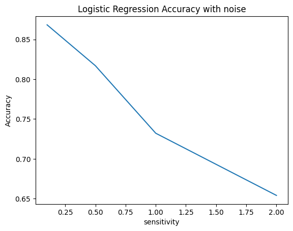

```python
print(f'Logistic Regression Accuracy is : {log_reg_serach.score(X_test,y_test) * 100:.2f} %')
results=[]
for i in range(len(sensitivity_range)):
    log_reg_serach = GridSearchCV(
        estimator=LogisticRegression(),
        param_grid={
        "C": [0.01, 0.1, 1, 10, 100],
        "penalty": ["l2"],
        "solver": ["newton-cg", "lbfgs", "liblinear", "sag", "saga"],
        },
        scoring="accuracy",
        cv=5,
        n_jobs=-1,
    )

    log_reg_serach.fit(noised_X_trains[i], y_train)
    results.append(log_reg_serach.score(noised_X_tests[i],y_test))

plt.plot(sensitivity_range, results)
plt.xlabel('sensitivity')
plt.ylabel('Accuracy')
plt.title('Logistic Regression Accuracy with noise')
plt.show()
```

#### KNN

```
KNN Accuracy is : 89.51 %
```

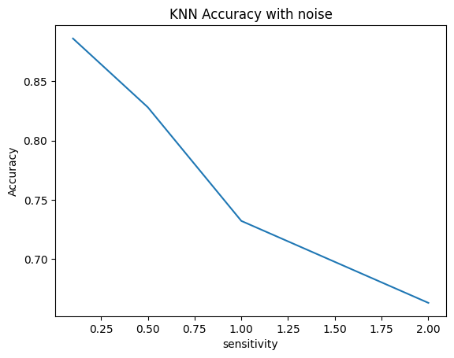

```python
print(f'KNN Accuracy is : {KNN_grid_search.score(X_test,y_test) * 100:.2f} %')
results=[]
for i in range(len(sensitivity_range)):
    KNN_grid_search = GridSearchCV(
        estimator=KNeighborsClassifier(),
        param_grid={
            "n_neighbors": list(range(1, 11)) + list(range(20, 101, 10)),
            "metric": ["euclidean", "manhattan", "minkowski"],
            "algorithm": ["auto", "ball_tree", "kd_tree", "brute"]
        },
        scoring="accuracy",
        cv=5,
        n_jobs=-1,
    )

    KNN_grid_search.fit(noised_X_trains[i], y_train)
    results.append(KNN_grid_search.score(noised_X_tests[i],y_test))

plt.plot(sensitivity_range, results)
plt.xlabel('sensitivity')
plt.ylabel('Accuracy')
plt.title('KNN Accuracy with noise')
plt.show()
```

#### Decision Tree

```
Decision Tree Accuracy is : 89.73 %
```

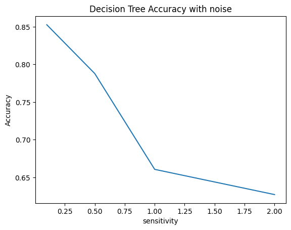

```python
print(f'Decision Tree Accuracy is : {decision_tree_search.score(X_test,y_test) * 100:.2f} %')
results=[]
for i in range(len(sensitivity_range)):
    decision_tree_model = DecisionTreeClassifier()
    decision_tree_model.fit(noised_X_trains[i], y_train)
    results.append(decision_tree_model.score(noised_X_tests[i],y_test))

plt.plot(sensitivity_range, results)
plt.xlabel('sensitivity')
plt.ylabel('Accuracy')
plt.title('Decision Tree Accuracy with noise')
plt.show()
```

## Gradient Boosting

### Q29

`Gradient Boosting` :  
Gradient boosting is a machine learning technique that combines multiple weak prediction models, typically decision trees, to create a strong predictive model. It sequentially builds new models to correct the mistakes made by the previous models. By combining these models, gradient boosting improves prediction accuracy and generalization. It uses gradient descent to minimize a loss function and combines predictions from multiple trees. Regularization techniques are applied to control model complexity and prevent overfitting.

*Differnces* :

`Single Model vs. Ensemble`: Decision trees are standalone models that make predictions based on a single tree structure. In contrast, gradient boosting is an ensemble method that combines multiple decision trees to create a more accurate and robust model. It sequentially builds a series of trees, where each subsequent tree corrects the mistakes made by the previous trees.

`Iterative Learning`: Decision trees are typically constructed in a top-down manner, recursively partitioning the data based on feature thresholds. In contrast, gradient boosting is an iterative process. It starts with an initial model and then builds subsequent models to minimize the errors made by the previous models.

`Handling Complexity`: Decision trees can handle complex patterns and interactions in the data. However, they're prone to overfitting, especially when the tree depth increases. Gradient boosting addresses this limitation by combining multiple shallow trees.

`Regularization`: Decision trees can easily grow to fit the training data precisely, potentially leading to overfitting. Gradient boosting incorporates regularization techniques to control model complexity and prevent overfitting.

### Q30

The core idea behind XGBoost is to iteratively add new decision trees to the ensemble while minimizing a specific objective function. This objective function consists of two components: a loss function that measures the difference between predicted and actual values, and a regularization term that controls the complexity of the model and helps prevent overfitting.

To start, XGBoost initializes with a simple decision tree, such as one with only a single leaf node. This initial tree predicts the average value of the target variable for all training examples. Then, in each iteration, XGBoost calculates the gradient (slope) of the loss function with respect to the predicted values from the previous iteration. This gradient represents the direction and magnitude of the steepest descent, indicating how much the predicted values need to be adjusted to minimize the loss.

Using gradient boosting, XGBoost adds new decision trees to the ensemble to correct the mistakes made by the previous trees. Each new tree is trained to minimize the loss function by fitting the negative gradient of the loss. The learning is "additive" because each new tree is trained to gradually reduce the residual errors of the ensemble.

To ensure model generalization and prevent overfitting, XGBoost incorporates regularization techniques. It applies regularization to the structure of the trees by adding penalties to the objective function that discourage complex and over-specialized trees. This helps control the depth, width, and number of leaf nodes in each tree.

The construction of decision trees in XGBoost follows a depth-wise approach. It starts by finding the best split points at the root of the tree based on the gradients of the loss function. Then, it recursively splits the tree by evaluating the quality of splits at each level until a stopping criterion is met. After tree construction, XGBoost performs tree pruning iteratively to remove unnecessary nodes that do not contribute significantly to the overall reduction in the objective function.

Once the training process is complete, predictions are made by aggregating the predictions of all the trees in the ensemble. The final prediction is the sum of the predictions made by each individual tree, weighted by a factor determined during the training procedure.

XGBoost offers various hyperparameters that allow users to control the learning process and model complexity. These hyperparameters include the learning rate, which determines the contribution of each tree to the final prediction, and the maximum depth of the trees, which controls the tree complexity.

### Q31

Some of the hyperparameters of the `XGBClassifier` are :

1. `learning_rate`:  
   It controls the learning rate which determines the contribution of each tree to the final ensemble. A lower value makes the model more robust by reducing the impact of each individual tree, but it may require more trees to achieve the same level of performance.
2. `max_depth`:  
   It sets the maximum depth of each tree in the ensemble. Deeper trees can capture more complex relationships in the data but may overfit.
3. `n_estimators`:  
   The number of decision trees in the ensemble. Increasing this value can make the model more accurate, but may also increase the risk of overfitting and make the model slower to train.
4. `gamma`: The minimum reduction in the loss function required to make a split at a node.

```python
xgb_grid_search = GridSearchCV(
    estimator=XGBClassifier(),
    param_grid={
        'max_depth': range(3,11,2),
        'learning_rate': [0.01, 0.03, 0.09, 0.1],
        'n_estimators': range(20,201,30),
        'gamma': [0, 1, 10, 100]
    },
    cv=5,
    scoring="accuracy"
)
xgb_grid_search.fit(X_train,encoded_y_train)
print(f"Best Accuracy in train data is : {xgb_grid_search.best_score_ * 100:.2f} %")
print(f"Best Accuracy in test data is : {xgb_grid_search.score(X_test, encoded_y_test) * 100:.2f} %")
print(f"Best Parameters are : {xgb_grid_search.best_params_}")
```

```
Best Accuracy in train data is : 93.41 %
Best Accuracy in test data is : 90.62 %
Best Parameters are : {'gamma': 0, 'learning_rate': 0.1, 'max_depth': 3, 'n_estimators': 170}
```

# Conclusion

This project successfully utilized linear regression and classification techniques to analyze and predict data. Linear regression helped model relationships between variables, while classification accurately categorized data into distinct groups. These techniques provided valuable insights and accurate predictions, with applications in diverse fields. Further refinement of these methods can lead to even more precise results in future data analysis projects.